# pract_2_YevgeniiYatsentiuk

## Практична робота № 2 Асимптотична складність алгоритмів. Інші нотації

## Мета: набути практичних навичок у розв’язанні задач на оцінку асимптотичної складності алгоритмів у Ω, Θ, 𝜊, 𝜃, 𝜔-нотаціях.

### Виконав: Яцентюк Євгеній, група: КІ-24-1

**[GitHub](https://github.com/kefir4ikk)**

Вибір варіанта Згідно з правилом $n, n+5$, де $n=23$ (номер у списку):

1. Задача 1: $23 - 15 = 8$
2. Задача 2: $23 + 5 = 28 \rightarrow 28 - 15 = 13$.

## Метод меж

Для порівняння порядку зростання функцій $f(n)$ та $g(n)$ обчислюється межа: $$L = \lim_{n \to \infty} \frac{f(n)}{g(n)}$$

Інтерпретація результату:

- Якщо $L = 0$, то $f(n)$ зростає повільніше за $g(n)$ ($f(n) = o(g(n)) \implies f(n) = O(g(n))$).
- Якщо $L = c > 0$ (константа), то функції зростають однаково швидко ($f(n) = \Theta(g(n))$).
- Якщо $L = \infty$, то $f(n)$ зростає швидше ($f(n) = \omega(g(n))$).

## Завдання 1 (№ 8 у списку)

**Умова:** Маємо функції $f(n) = 2n^3 - 4n^2 + 8$ (відновлено з контексту як поліном 3-го ступеня) та $g(n) = n^4$. Показати, що $f(n) = O(g(n))$, використовуючи метод меж.

**Розв'язання:** Знайдемо межу відношення функцій при $n \to \infty$:

$$\lim_{n \to \infty} \frac{f(n)}{g(n)} = \lim_{n \to \infty} \frac{2n^3 - 4n^2 + 8}{n^4}$$

Розділимо чисельник почленно на знаменник:

$$= \lim_{n \to \infty} \left( \frac{2n^3}{n^4} - \frac{4n^2}{n^4} + \frac{8}{n^4} \right)$$ $$= \lim_{n \to \infty} \left( \frac{2}{n} - \frac{4}{n^2} + \frac{8}{n^4} \right)$$

Оскільки при $n \to \infty$ всі доданки прямують до 0: $$= 0 - 0 + 0 = 0$$

**Висновок:** Оскільки межа дорівнює $0$, це означає, що $f(n)$ зростає строго повільніше, ніж $g(n)$. Згідно з правилом методу меж (див. рис. 1.9 у методичці), якщо межа дорівнює 0, то $f(n) = o(g(n))$, що автоматично означає $f(n) = O(g(n))$.

Твердження доведено.

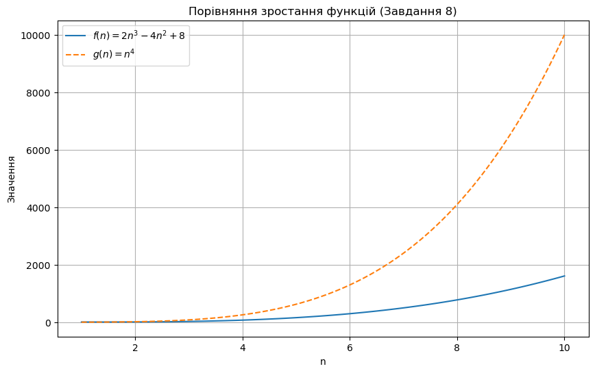

```python
import matplotlib.pyplot as plt
import numpy as np

n = np.linspace(1, 10, 100)

# Функції
f_n = 2 * n**3 - 4 * n**2 + 8
g_n = n**4

plt.figure(figsize=(10, 6))
plt.plot(n, f_n, label=r'$f(n) = 2n^3 - 4n^2 + 8$')
plt.plot(n, g_n, label=r'$g(n) = n^4$', linestyle='--')

plt.title('Порівняння зростання функцій (Завдання 8)')
plt.xlabel('n')
plt.ylabel('Значення')
plt.legend()
plt.grid(True)
plt.show()
```

## Завдання 2 (№ 13 у списку)

**Умова:** Задано функції $f(n) = n^3 - n^2 + 2$ та $g(n) = n^4$. Показати, що $f(n) = O(g(n))$, використовуючи метод меж.

**Розв'язання:** Обчислимо межу:

$$\lim_{n \to \infty} \frac{f(n)}{g(n)} = \lim_{n \to \infty} \frac{n^3 - n^2 + 2}{n^4}$$

Винесемо старший степінь $n^4$ у знаменнику або просто поділимо почленно:

$$= \lim_{n \to \infty} \left( \frac{n^3}{n^4} - \frac{n^2}{n^4} + \frac{2}{n^4} \right)$$ $$= \lim_{n \to \infty} \left( \frac{1}{n} - \frac{1}{n^2} + \frac{2}{n^4} \right)$$

Підставимо $n \to \infty$: $$= 0 - 0 + 0 = 0$$

**Висновок:** Оскільки межа дорівнює $0$, це підтверджує, що порядок зростання $f(n)$ менший за порядок $g(n)$. Отже, $f(n) = O(g(n))$ є вірним.

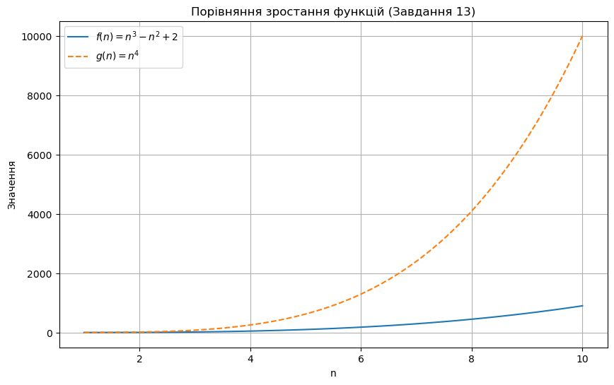

```python
n = np.linspace(1, 10, 100)

f_n_2 = n**3 - n**2 + 2
g_n_2 = n**4

plt.figure(figsize=(10, 6))
plt.plot(n, f_n_2, label=r'$f(n) = n^3 - n^2 + 2$')
plt.plot(n, g_n_2, label=r'$g(n) = n^4$', linestyle='--')

plt.title('Порівняння зростання функцій (Завдання 13)')
plt.xlabel('n')
plt.ylabel('Значення')
plt.legend()
plt.grid(True)
plt.show()
```

## Відповіді на контрольні питання

**1. Що таке асимптотична складність алгоритму?**

Це оцінка ефективності алгоритму, яка показує, як швидко зростає функція $f(n)$ (час виконання або обсяг пам'яті) при збільшенні розміру вхідних даних $n$ до нескінченності ($n \to \infty$). Нас цікавить не точне значення часу для конкретного $n$, а саме порядок (швидкість) зростання функції.

**2. Які інші нотації, крім $O$-нотації, використовуються для вираження асимптотичної складності?**

Окрім $O$-нотації (верхня межа), використовуються:

- $\Omega$ (Омега велика) — асимптотична нижня межа.
- $\Theta$ (Тета) — асимптотична точна оцінка.
- $o$ (о маленьке) — сувора верхня межа.
- $\omega$ (омега маленька) — сувора нижня межа.

**3. Як визначити асимптотичну складність алгоритму за допомогою символів $\Theta$ і $\Omega$?**

- **Для $\Omega$ (нижня межа):** Потрібно знайти такі константи $c > 0$ та $n_0$, щоб виконувалася нерівність $f(n) \ge c \cdot g(n)$ для всіх $n \ge n_0$. Це означає, що алгоритм працює *принаймні* так швидко, як $g(n)$ (або довше).
- **Для $\Theta$ (точна межа):** Потрібно знайти константи $c_1, c_2 > 0$ та $n_0$, щоб виконувалася подвійна нерівність $c_1 g(n) \le f(n) \le c_2 g(n)$ для всіх $n \ge n_0$. Це означає, що функція $f(n)$ обмежена функцією $g(n)$ і зверху, і знизу.

**4. Яка різниця між $O$-нотацією, $\Theta$-нотацією і $\Omega$-нотацією?**

- **$O(g(n))$**: Визначає **верхню** межу. Функція росте *не швидше* за $g(n)$.
- **$\Omega(g(n))$**: Визначає **нижню** межу. Функція росте *не повільніше* (принаймні так само швидко) за $g(n)$.
- **$\Theta(g(n))$**: Визначає **точну** межу. Функція росте *з тією ж швидкістю*, що й $g(n)$ (еквівалент "дорівнює" в асимптотичному сенсі).

**5. Які основні властивості інших нотацій, таких як $o$ (маленька о) та $\omega$ (маленька омега)?**

Ці нотації («малі» літери) є більш строгими варіантами асимптотичних оцінок порівняно з великими $O$ та $\Omega$. Вони вказують на те, що функції зростають з **різною** швидкістю (нерівність є строгою).

- **$o(g(n))$ — «о маленьке» (Сувора верхня межа):**
  - **Сутність:** Функція $f(n)$ зростає **строго повільніше**, ніж $g(n)$. Це означає, що $f(n)$ стає незначною порівняно з $g(n)$ при великих $n$.
  - **Математичне визначення:** $f(n) = o(g(n))$, якщо для **будь-якої** константи $c > 0$ знайдеться таке значення $n_0$, що для всіх $n \ge n_0$ виконується нерівність $f(n) < c \cdot g(n)$.
  - **Визначення через границю:** $\lim_{n \to \infty} \frac{f(n)}{g(n)} = 0$.
- **$\omega(g(n))$ — «омега маленька» (Сувора нижня межа):**
  - **Сутність:** Функція $f(n)$ зростає **строго швидше**, ніж $g(n)$.
  - **Математичне визначення:** $f(n) = \omega(g(n))$, якщо для **будь-якої** константи $c > 0$ знайдеться таке $n_0$, що для всіх $n \ge n_0$ виконується нерівність $f(n) > c \cdot g(n)$.
  - **Визначення через границю:** $\lim_{n \to \infty} \frac{f(n)}{g(n)} = \infty$.